# Yelp Data Wrangling Project

Rich Dean

22 October 2015

This document covers my initial exploration of the Yelp Dataset Challenge data. This dataset from the online review site Yelp, and is part of a data anlysis competition, now in its fifth run. The data contains (from the Yelp website):

- 1.6M reviews and 500K tips by 366K users for 61K businesses
- 481K business attributes, e.g., hours, parking availability, ambience.
- Social network of 366K users for a total of 2.9M social edges.
- Aggregated check-ins over time for each of the 61K businesses

### Initialisation

To start, I’ll import my libraries, include files, and set globals variables. After that, I’ll load in the data (from cache if available).

```r
library(jsonlite)
library(ggmap)
library(ggplot2)
library(GGally)
library(RColorBrewer)
library(tidyr)
library(dplyr)
# Include my standard function library
source(file="~/R_code/common/rrfuncs.R")
# Optionally clear my environment - makes things clearer
# rm(list=ls())
data_dir = c('~/datasets/yelp/')
```

```r
if (file.exists(paste0(data_dir,'yelp_data.Rd')))
{
  load(paste0(data_dir,'yelp_data.Rd'))
} else {
  # The data is in a line-by-line JSON format, rather than fully-compliant JSON.
  # Use 'stream_in' from jsonlite
  y.business <- stream_in(file(paste0(data_dir,
                                      "yelp_academic_dataset_business.json")))
  y.checkin <- stream_in(file(paste0(data_dir,
                                     "yelp_academic_dataset_checkin.json")))
  y.review <- stream_in(file(paste0(data_dir,
                                    "yelp_academic_dataset_review.json")))
  y.tip <- stream_in(file(paste0(data_dir,"yelp_academic_dataset_tip.json")))
  y.user <- stream_in(file(paste0(data_dir,"yelp_academic_dataset_user.json")))
  # Cache the R data
  save(list=c('y.business','y.user','y.review','y.tip','y.checkin'),
       file=paste0(data_dir,'yelp_data.Rd'))
}
```

Now that the data is loaded, I’ll quickly verify the Yelp statements about the dataset size, and take a quick look at the structure of the **y.business** data frame.

```r
data.frame(rbind(
    c(Stat='Reviews',Rows=nrow(y.review)),
    c('Tips', nrow(y.tip)),
    c('Users', nrow(y.user)),
    c('Businesses', nrow(y.business)))
  )
```

```
##         Stat    Rows
## 1    Reviews 1569264
## 2       Tips  495107
## 3      Users  366715
## 4 Businesses   61184
```

```r
# Use max.level, as this is a coplex nested frame
str(y.business, max.level=1)
```

```
## 'data.frame':    61184 obs. of  15 variables:
##  $ business_id  : chr  "vcNAWiLM4dR7D2nwwJ7nCA" "UsFtqoBl7naz8AVUBZMjQQ" "cE27W9VPgO88Qxe4ol6y_g" "HZdLhv6COCleJMo7nPl-RA" ...
##  $ full_address : chr  "4840 E Indian School Rd\nSte 101\nPhoenix, AZ 85018" "202 McClure St\nDravosburg, PA 15034" "1530 Hamilton Rd\nBethel Park, PA 15234" "301 S Hills Vlg\nPittsburgh, PA 15241" ...
##  $ hours        :'data.frame':   61184 obs. of  7 variables:
##  $ open         : logi  TRUE TRUE FALSE TRUE TRUE TRUE ...
##  $ categories   :List of 61184
##   .. [list output truncated]
##  $ city         : chr  "Phoenix" "Dravosburg" "Bethel Park" "Pittsburgh" ...
##  $ review_count : int  9 4 5 3 11 15 5 4 3 8 ...
##  $ name         : chr  "Eric Goldberg, MD" "Clancy's Pub" "Cool Springs Golf Center" "Verizon Wireless" ...
##  $ neighborhoods:List of 61184
##   .. [list output truncated]
##  $ longitude    : num  -112 -79.9 -80 -80.1 -79.9 ...
##  $ state        : chr  "AZ" "PA" "PA" "PA" ...
##  $ stars        : num  3.5 3.5 2.5 3.5 4.5 4 1.5 4 2.5 3.5 ...
##  $ latitude     : num  33.5 40.4 40.4 40.4 40.4 ...
##  $ attributes   :'data.frame':   61184 obs. of  38 variables:
##  $ type         : chr  "business" "business" "business" "business" ...
```

## Geography

I know that the businesses are located in 10 distinct areas. I have their names, and the **latitude**/**longitude** are in the **y.business** object. I’ll use k-means clustering to label the groups, which will allow for some comparative geo-analysis. I have the list of actual locations which the data should be from, so i will seed the kmeans with the lat/long of those ten locations.

```r
cities<-c('Edinburgh, UK', 'Karlsruhe, Germany', 'Montreal, Canada',
          'Waterloo, Canada', 'Pittsburgh, PA', 'Charlotte, NC',
          'Urbana-Champaign, IL', 'Phoenix, AZ', 'Las Vegas, NV', 'Madison, WI')
region.centres<-geocode(cities, source='google')
set.seed(43046721)
myclus<-kmeans(y.business[,c('longitude','latitude')],region.centres)
y.business$location<-cities[myclus$cluster]
table(y.business$location, y.business$state)
```

```
##
##                           AZ    BW    CA   EDH   ELN   FIF   HAM    IL
##   Charlotte, NC            0     0     0     0     0     0     0     0
##   Edinburgh, UK            0     0     0  2971    10     4     1     0
##   Karlsruhe, Germany       0   934     0     0     0     0     0     0
##   Las Vegas, NV            0     0     2     0     0     0     0     0
##   Madison, WI              0     0     0     0     0     0     0     0
##   Montreal, Canada         0     0     0     0     0     0     0     0
##   Phoenix, AZ          25230     0     1     0     0     0     0     0
##   Pittsburgh, PA           0     0     0     0     0     0     0     0
##   Urbana-Champaign, IL     0     0     0     0     0     0     0   627
##   Waterloo, Canada         0     0     0     0     0     0     0     0
##
##                          KHL    MA   MLN    MN    NC   NTH    NV    NW
##   Charlotte, NC            0     0     0     0  4962     0     0     0
##   Edinburgh, UK            1     0   123     0     0     1     0     0
##   Karlsruhe, Germany       0     0     0     0     0     0     0     1
##   Las Vegas, NV            0     0     0     0     1     0 16485     0
##   Madison, WI              0     1     0     1     0     0     0     0
##   Montreal, Canada         0     0     0     0     0     0     0     0
##   Phoenix, AZ              0     0     0     0     0     0     0     0
##   Pittsburgh, PA           0     0     0     0     0     0     0     0
##   Urbana-Champaign, IL     0     0     0     0     0     0     0     0
##   Waterloo, Canada         0     0     0     0     0     0     0     0
##
##                           ON    OR    PA    QC    RP    SC   SCB    WA
##   Charlotte, NC            0     0     0     0     0   189     0     0
##   Edinburgh, UK            0     0     0     0     0     0     3     0
##   Karlsruhe, Germany       0     0     0     0    13     0     0     0
##   Las Vegas, NV            0     1     0     0     0     0     0     1
##   Madison, WI              0     0     0     0     0     0     0     0
##   Montreal, Canada         0     0     0  3921     0     0     0     0
##   Phoenix, AZ              0     0     0     0     0     0     0     0
##   Pittsburgh, PA           0     0  3041     0     0     0     0     0
##   Urbana-Champaign, IL     0     0     0     0     0     0     0     0
##   Waterloo, Canada       351     0     0     0     0     0     0     0
##
##                           WI   XGL
##   Charlotte, NC            0     0
##   Edinburgh, UK            0     1
##   Karlsruhe, Germany       0     0
##   Las Vegas, NV            0     0
##   Madison, WI           2307     0
##   Montreal, Canada         0     0
##   Phoenix, AZ              0     0
##   Pittsburgh, PA           0     0
##   Urbana-Champaign, IL     0     0
##   Waterloo, Canada         0     0
```

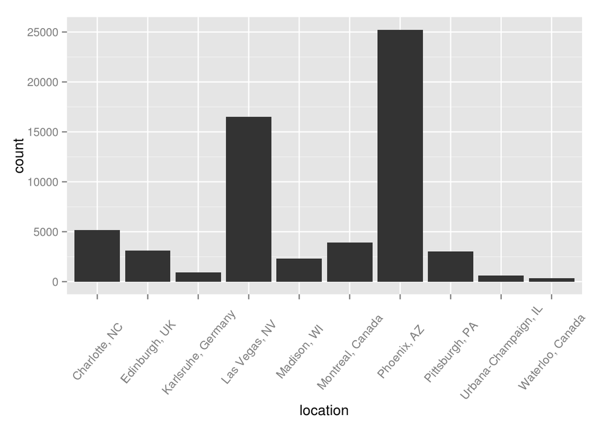

```r
ggplot(data=y.business, aes(x=location)) +
  geom_histogram() +
  theme(axis.text.x=element_text(angle=50, size=10, vjust=0.5))
```

```r
subset(y.business, state=='NC' & location=='Las Vegas, NV')$full_address
```

```
## [1] "3890 Blue Diamond Rd\nSuite C\nSouthwest\nLas Vegas, NC 89139"
```

It’s a typo! Yelp must take the **state** value from the entered address. I’ll do a pair of map plots - one for the US, and one for Europe - to show the distribution of the business, coloured by the cluster.

[figure not shown]

```r
europe.centre <- colMeans(apply(myclus$centers[cities %in%
                            c('Edinburgh, UK','Karlsruhe, Germany'),],2,range))
map.europe <- get_map(location = europe.centre, zoom = 6)
map1<-ggmap(map.europe) +
    geom_point(aes(x=longitude, y=latitude, color=location),
               data=subset(y.business,
                        location %in% c('Edinburgh, UK','Karlsruhe, Germany')))

usa.centre <- colMeans(apply(myclus$centers[!cities %in%
                            c('Edinburgh, UK','Karlsruhe, Germany'),],2,range))
map.usa <- get_map(location = usa.centre, zoom = 4)
map2<-ggmap(map.usa) +
    geom_point(aes(x=longitude, y=latitude, color=location),
               data=subset(y.business,
                        !location %in% c('Edinburgh, UK','Karlsruhe, Germany')))

map1
```

[figure not shown]

```r
map2
```

The maps show that the clustering worked nicely, and also shows the geographic spread of the businesses in the dataset. Despite the scale of the USA map, you can see something of the dispersal of businesses within each cluster - the Phoenix AZ cluster is the largest of the groups on the map, while the Urbana-Champaign IL group is smallest.

I’ll add a distance to the cluster center too - I can then do some analysis of the area covered by each cluster This is only for a comparative measure, and the distances /should/ be relatively short, so i won’t go so far as a great circle calculation

```r
t.distance<-y.business[,c('longitude','latitude')]-myclus$centers[
                                                                myclus$cluster,]
y.business$distance.from.centre<-sqrt(rowSums(t.distance**2))
tbl_df(y.business[,c('location','distance.from.centre')]) %>%
  group_by(location) %>%
  summarise(mn=mean(distance.from.centre), sd=sd(distance.from.centre))
```

```
## Source: local data frame [10 x 3]
##
##                location         mn         sd
##                   (chr)      (dbl)      (dbl)
## 1         Charlotte, NC 0.09622936 0.05922118
## 2         Edinburgh, UK 0.02252761 0.02907276
## 3    Karlsruhe, Germany 0.03526781 0.03735799
## 4         Las Vegas, NV 0.08950494 0.05578469
## 5           Madison, WI 0.07210386 0.04991131
## 6      Montreal, Canada 0.05166342 0.05228179
## 7           Phoenix, AZ 0.19152956 0.12064225
## 8        Pittsburgh, PA 0.04853231 0.03025525
## 9  Urbana-Champaign, IL 0.01798966 0.01288208
## 10     Waterloo, Canada 0.04142594 0.03097660
```

This shows that Urbana-Champaign has the tightest group of businesses (low mean and standard deviation), while Phoenix has the most dispersed, as seen on the map plots.

## Business Categories

I’d also like to get a primary category for each business - this will also simplify analysis. The primary category list is taken from https://www.yelp.com/developers/documentation/v2/all_category_list.

```r
yelp.primary.categories<-
  c('Active Life','Arts & Entertainment','Automotive','Beauty & Spas',
    'Education','Event Planning & Services','Financial Services','Food',
    'Health & Medical','Home Services','Hotels & Travel','Local Flavor',
    'Local Services','Mass Media','Nightlife','Pets','Professional Services',
    'Public Services & Government','Real Estate','Religious Organizations',
    'Restaurants','Shopping')

y.business$primary.categories<-
  lapply(y.business$categories,
         function (x) sort(intersect(x, yelp.primary.categories)))
length(unique(y.business$primary.categories))
```

```
## [1] 325
```

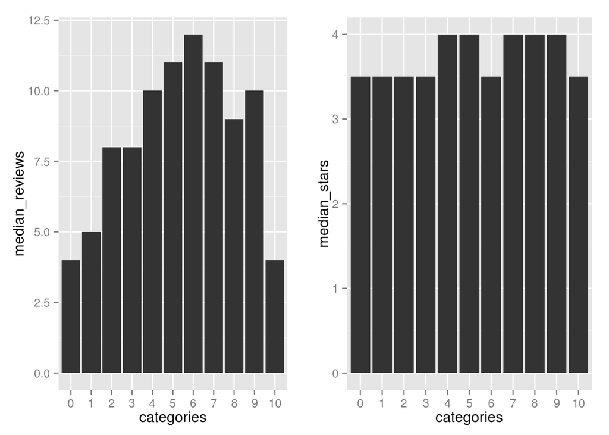

```r
cat.dist<-
  data.frame(categories=
               as.factor(
                 sapply(y.business$categories,
                        function(x) length(unlist(x)))),
             location=y.business$location,
             reviews=y.business$review_count,
             stars=y.business$stars)
# Build a second variable to hold summaries
cat.dist2<- cat.dist %>%
            group_by(categories) %>%
            summarise(median_reviews=median(reviews),
                      median_stars=median(stars),
                      n=n())
rr.multiplot(
  ggplot(data=cat.dist2, aes(x=categories)) +
    geom_histogram(aes(y=median_reviews), stat='identity'),
  ggplot(data=cat.dist2, aes(x=categories)) +
    geom_histogram(aes(y=median_stars), stat='identity'),
  cols=2)
```

There isn’t a clear link between the ratings and number of categories, but there appears to be a clear link between categories and number of reviews

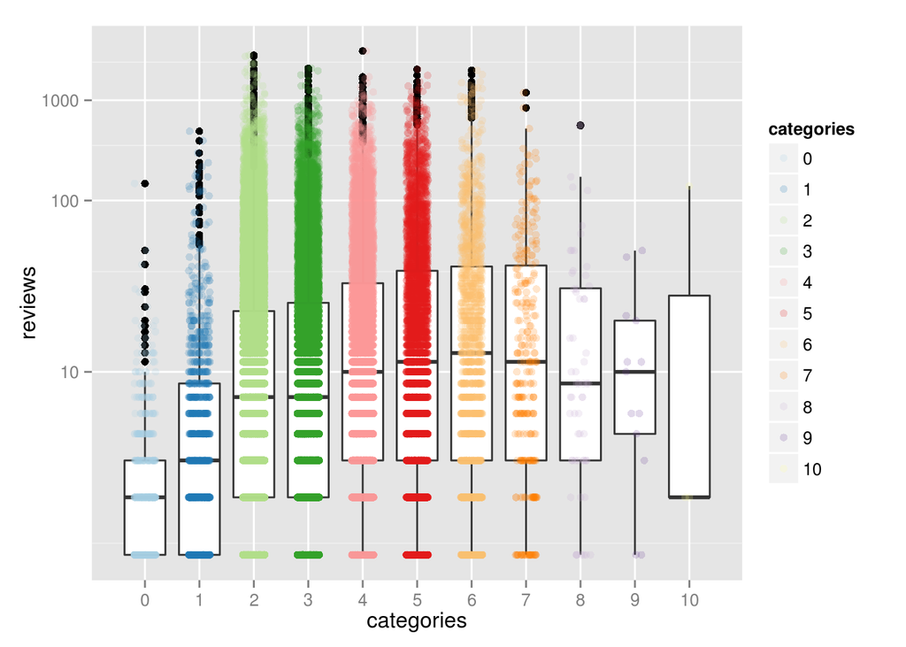

```r
ggplot(data=cat.dist, aes(x=categories, y=reviews)) +
  coord_trans(ytrans='log10') +
  geom_boxplot() +
  geom_jitter(alpha=0.2, aes(color=categories),
              position=position_jitter(width=.2))+
  scale_colour_brewer('categories', palette='Paired') +
  scale_y_log10()
```

Using a log plot of reviews shows there are actually few businesses with very high numbers of reviews. The point density shows the bulk of businesses have between 2 and 5 categories, and less than 100 reviews

## Checkins

I had hoped to perform more category-based analysis, but with multiple primary categories, I would have to sift the combinations and derive so kind of hierarchy to determine a single primary for each business. Instead, I chose to look into a different view of the data - checkins. This shows when businesses are visited, by week-hour. The **y.checkin** data frame contains my core data - I’ll add some of the columns from **y.business** to provide a more useful single frame. I will use heatmaps to visualise this data.

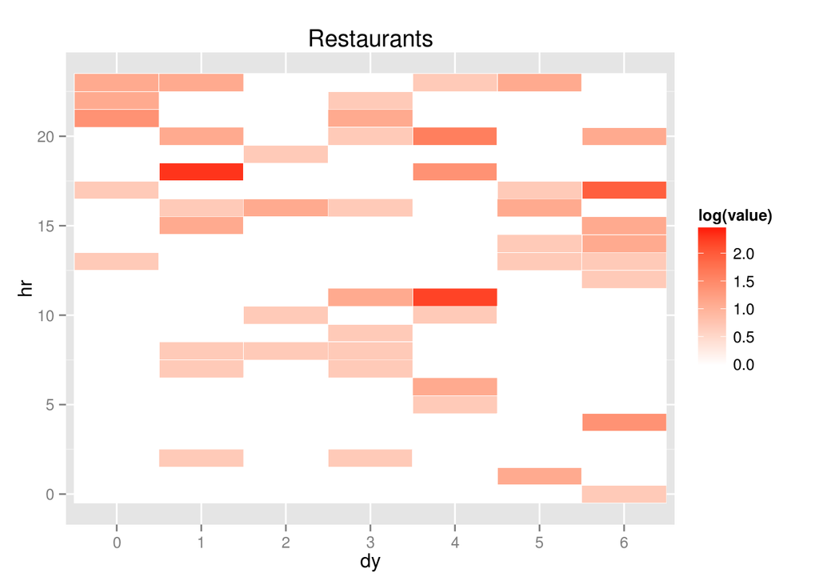

```r
y.checkin<-data.frame(flatten(y.checkin))
y.checkin<-
  y.checkin %>%
  left_join(y.business[,c('business_id','location','review_count',
                          'stars', 'primary.categories')],
            by = 'business_id')
# Need to gather the checkin_info columns
# I'll split the check-in column names to give hour/day values
y.checkin.long <-
  y.checkin %>%
  gather(key, value, -location, -stars, -review_count, -type, -business_id,
         -primary.categories, na.rm=TRUE) %>%
  mutate(checkin.list= strsplit(as.character(key), '\\.')) %>%
  mutate(hr = as.integer(sapply(checkin.list, function (x) x[2])),
         dy = sapply(checkin.list, function (x) x[3])) %>%
  select(-key, -checkin.list, -type, -business_id)

# Break the primary category list into columns
# This code from http://stackoverflow.com/questions/25347739/r-convert- \\
#                     factor-column-to-multiple-boolean-columns
lvl <- unique(unlist(y.checkin.long$primary.categories))
res <- data.frame(do.call(rbind,lapply(y.checkin.long$primary.categories,
                                       function(x) table(factor(x, levels=lvl)))
                          ),
                  stringsAsFactors=FALSE)
y.checkin.long<-cbind(y.checkin.long, res)


#  Lets look at restaurants, nightlife, and religious organisations
rt.heatmap <- function (l.criteria, loc_wrap = FALSE)
{
  p<-ggplot(subset(y.checkin.long, eval(parse(text=l.criteria))), aes(dy, hr)) +
    geom_tile(aes(fill = log(value)), colour = "white") +
    scale_fill_gradient(low = "white", high = "red")
  p + if (loc_wrap==TRUE) facet_wrap( ~ location ) else NULL
}

rt.heatmap('Restaurants>0&value<quantile(value,0.95)')+ggtitle('Restaurants')
```

I would have expected to see a pattern in restaurant checkins - more frequent at lunchtimes and evenings - but there are no clear patterns to be seen in this plot. The *nightlife* category should clearly show a pattern…

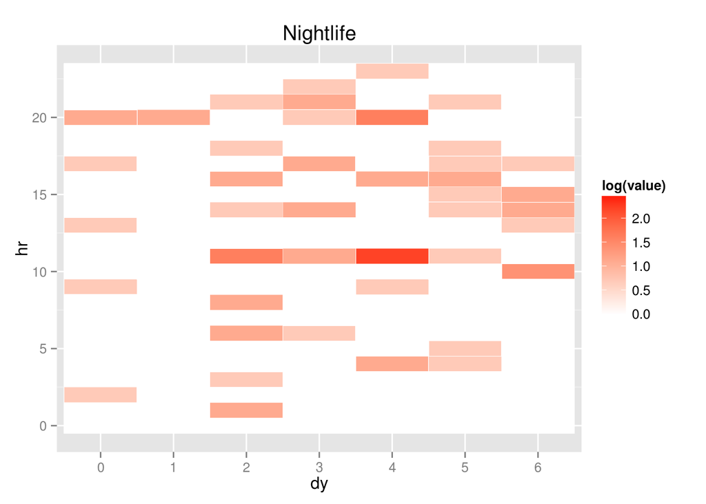

```r
rt.heatmap('Nightlife>0&value<quantile(value,0.95)')+ggtitle('Nightlife')
```

This very puzzling. The checkins seem to be widely scattered. A final look at these, taking Religious Organisations and splitting by location…

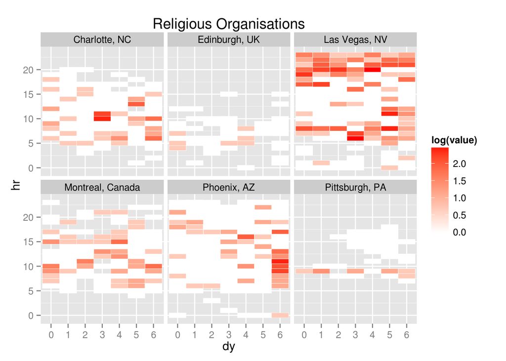

```r
rt.heatmap('Religious.Organizations>0&value<quantile(value,0.95)', TRUE)+
  ggtitle('Religious Organisations')
```